# Assignment9

Jeff Moise

11/4/2019

1. This following codes build a predictive model to predict if a passenger in the titanic is survived or not. A common practice is to split the data into 2 subdata: a train data and a test data. The model is build from the train data and then tested on the test data.

```r
library(readr)
titanic <- read_csv(file="C:\\Users\\student\\Documents\\R\\titanic.csv")
titanic$target <- titanic$Survived
library(tidyverse)
titanic <- titanic %>%
select(-c(Ticket,Name,Cabin,Survived)) %>% drop_na

titanic$target <- factor(titanic$target)

head(titanic)
```

```
## # A tibble: 6 x 9
##   PassengerId Pclass Sex      Age SibSp Parch  Fare Embarked target
##         <dbl>  <dbl> <chr>  <dbl> <dbl> <dbl> <dbl> <chr>    <fct>
## 1           1      3 male      22     1     0  7.25 S        0
## 2           2      1 female    38     1     0 71.3  C        1
## 3           3      3 female    26     0     0  7.92 S        1
## 4           4      1 female    35     1     0 53.1  S        1
## 5           5      3 male      35     0     0  8.05 S        0
## 6           7      1 male      54     0     0 51.9  S        0
```

```r
# Split the data into 70% training and 30% testing
library(caret)
```

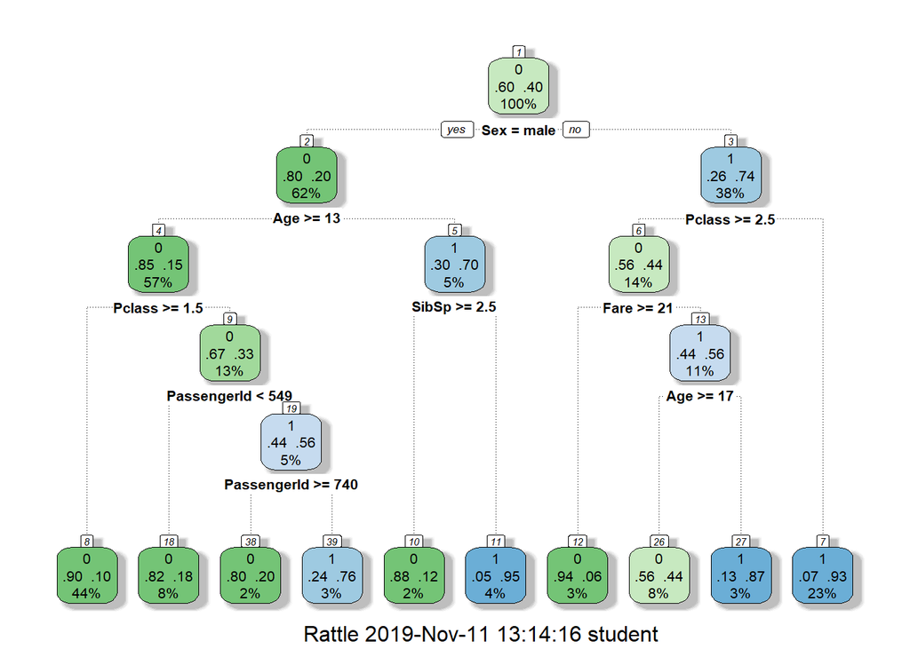

```r
splitIndex <- createDataPartition(titanic$target, p = .70, list = FALSE)
train <- titanic[ splitIndex,]
test <- titanic[-splitIndex,]

library(rpart) #load the rpart package

# build a tree
mytree <- rpart(target ~ ., data = train, method = "class")

# Plot the tree
library(rattle)
fancyRpartPlot(mytree)
```

[figure not shown]

```r
# Evaluate the tree on the testing data

#predict on testing data
pred <- predict(mytree,test, type = "class")

#Evaluate the predictions

cm=confusionMatrix(data = pred, reference = factor(test$target), positive = "1")

# build a tree
mytree <- rpart(target ~ ., data = train, method = "class")

# Plot the tree
library(rattle)
fancyRpartPlot(mytree)
```

[figure not shown]

```r
# Evaluate the tree on the testing data

#predict on testing data
pred <- predict(mytree,test, type = "class")

#Evaluate the predictions
cm=confusionMatrix(data = pred, reference = factor(test$target), positive = "1")

# Build another tree
# Tree with depth=2
mytree2 <- rpart(target ~ ., data = train, method = "class", control = rpart.control(maxdepth = 3))
fancyRpartPlot(mytree2)
```

Compute the training error of a decision tree with maxdepth=1

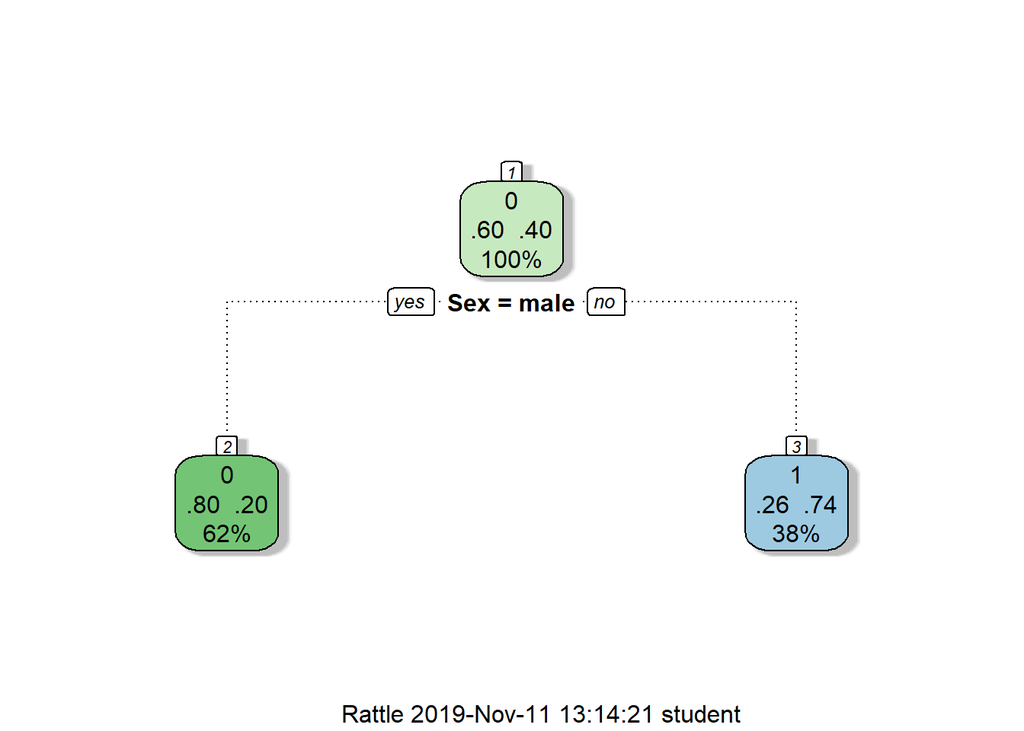

```r
jefftree <- rpart(target ~ ., data = train, method = "class", control = rpart.control(maxdepth = 1))
fancyRpartPlot(jefftree)
```

```r
pred <- predict(jefftree,train, type = "class")

confusionMatrix(data = pred, reference = factor(train$target), positive = "1")
```

```
## Confusion Matrix and Statistics
##
##           Reference
## Prediction   0   1
##          0 249  62
##          1  48 140
##
##                Accuracy : 0.7796
##                  95% CI : (0.7406, 0.8152)
##     No Information Rate : 0.5952
##     P-Value [Acc > NIR] : <2e-16
##
##                   Kappa : 0.5374
##
##  Mcnemar's Test P-Value : 0.2152
##
##             Sensitivity : 0.6931
##             Specificity : 0.8384
##          Pos Pred Value : 0.7447
##          Neg Pred Value : 0.8006
##              Prevalence : 0.4048
##          Detection Rate : 0.2806
##    Detection Prevalence : 0.3768
##       Balanced Accuracy : 0.7657
##
##        'Positive' Class : 1
##
```

Compute the training errors of decision trees with maxdepth running from 1 to 10. How does the training error change when the maxdepth increases.

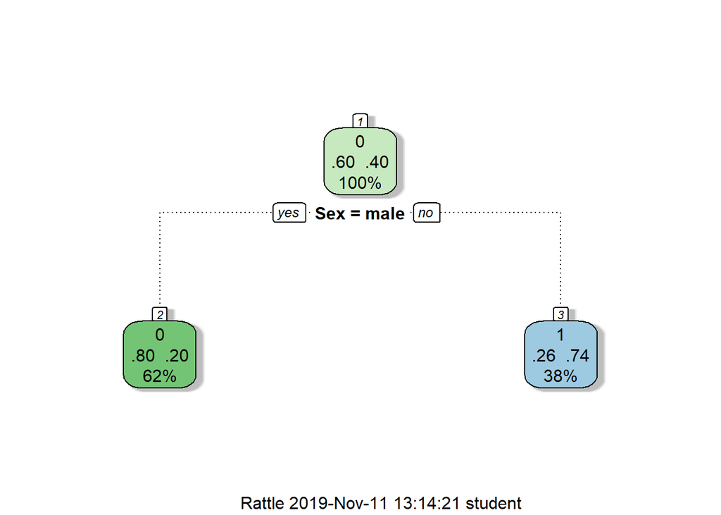

```
## Confusion Matrix and Statistics
##
##           Reference
## Prediction   0   1
##          0 249  62
##          1  48 140
##
##                Accuracy : 0.7796
##                  95% CI : (0.7406, 0.8152)
##     No Information Rate : 0.5952
##     P-Value [Acc > NIR] : <2e-16
##
##                   Kappa : 0.5374
##
##  Mcnemar's Test P-Value : 0.2152
##
##             Sensitivity : 0.6931
##             Specificity : 0.8384
##          Pos Pred Value : 0.7447
##          Neg Pred Value : 0.8006
##              Prevalence : 0.4048
##          Detection Rate : 0.2806
##    Detection Prevalence : 0.3768
##       Balanced Accuracy : 0.7657
##
##        'Positive' Class : 1
##
```

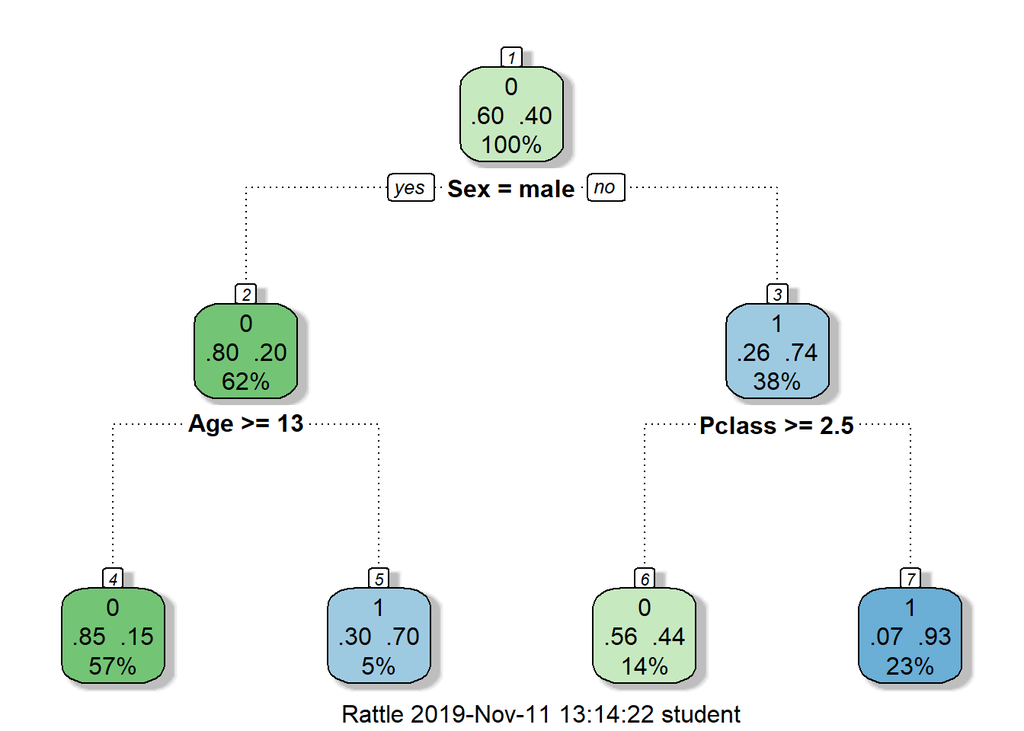

```
## Confusion Matrix and Statistics
##
##           Reference
## Prediction   0   1
##          0 281  74
##          1  16 128
##
##                Accuracy : 0.8196
##                  95% CI : (0.783, 0.8524)
##     No Information Rate : 0.5952
##     P-Value [Acc > NIR] : < 2.2e-16
##
##                   Kappa : 0.6077
##
##  Mcnemar's Test P-Value : 1.874e-09
##
##             Sensitivity : 0.6337
##             Specificity : 0.9461
##          Pos Pred Value : 0.8889
##          Neg Pred Value : 0.7915
##              Prevalence : 0.4048
##          Detection Rate : 0.2565
##    Detection Prevalence : 0.2886
##       Balanced Accuracy : 0.7899
##
##        'Positive' Class : 1
##
```

[figure not shown]

```
## Confusion Matrix and Statistics
##
##           Reference
## Prediction   0   1
##          0 264  45
##          1  33 157
##
##                Accuracy : 0.8437
##                  95% CI : (0.8088, 0.8744)
##     No Information Rate : 0.5952
##     P-Value [Acc > NIR] : <2e-16
##
##                   Kappa : 0.6725
##
##  Mcnemar's Test P-Value : 0.2129
##
##             Sensitivity : 0.7772
##             Specificity : 0.8889
##          Pos Pred Value : 0.8263
##          Neg Pred Value : 0.8544
##              Prevalence : 0.4048
##          Detection Rate : 0.3146
##    Detection Prevalence : 0.3808
##       Balanced Accuracy : 0.8331
##
##        'Positive' Class : 1
##
```

[figure not shown]

```
## Confusion Matrix and Statistics
##
##           Reference
## Prediction   0   1
##          0 286  62
##          1  11 140
##
##                Accuracy : 0.8537
##                  95% CI : (0.8196, 0.8835)
##     No Information Rate : 0.5952
##     P-Value [Acc > NIR] : < 2.2e-16
##
##                   Kappa : 0.6836
##
##  Mcnemar's Test P-Value : 4.855e-09
##
##             Sensitivity : 0.6931
##             Specificity : 0.9630
##          Pos Pred Value : 0.9272
##          Neg Pred Value : 0.8218
##              Prevalence : 0.4048
##          Detection Rate : 0.2806
##    Detection Prevalence : 0.3026
##       Balanced Accuracy : 0.8280
##
##        'Positive' Class : 1
##
```

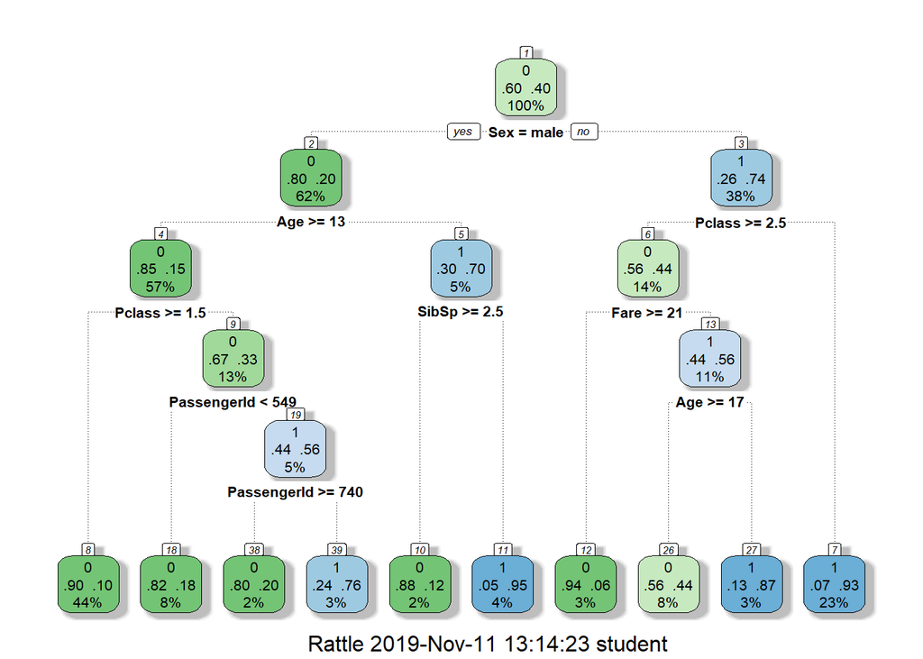

```
## Confusion Matrix and Statistics
##
##           Reference
## Prediction   0   1
##          0 282  49
##          1  15 153
##
##                Accuracy : 0.8717
##                  95% CI : (0.8392, 0.8998)
##     No Information Rate : 0.5952
##     P-Value [Acc > NIR] : < 2.2e-16
##
##                   Kappa : 0.7265
##
##  Mcnemar's Test P-Value : 3.707e-05
##
##             Sensitivity : 0.7574
##             Specificity : 0.9495
##          Pos Pred Value : 0.9107
##          Neg Pred Value : 0.8520
##              Prevalence : 0.4048
##          Detection Rate : 0.3066
##    Detection Prevalence : 0.3367
##       Balanced Accuracy : 0.8535
##
##        'Positive' Class : 1
##
```

[figure not shown]

```
## Confusion Matrix and Statistics
##
##           Reference
## Prediction   0   1
##          0 282  49
##          1  15 153
##
##                Accuracy : 0.8717
##                  95% CI : (0.8392, 0.8998)
##     No Information Rate : 0.5952
##     P-Value [Acc > NIR] : < 2.2e-16
##
##                   Kappa : 0.7265
##
##  Mcnemar's Test P-Value : 3.707e-05
##
##             Sensitivity : 0.7574
##             Specificity : 0.9495
##          Pos Pred Value : 0.9107
##          Neg Pred Value : 0.8520
##              Prevalence : 0.4048
##          Detection Rate : 0.3066
##    Detection Prevalence : 0.3367
##       Balanced Accuracy : 0.8535
##
##        'Positive' Class : 1
##
```

[figure not shown]

```
## Confusion Matrix and Statistics
##
##           Reference
## Prediction   0   1
##          0 282  49
##          1  15 153
##
##                Accuracy : 0.8717
##                  95% CI : (0.8392, 0.8998)
##     No Information Rate : 0.5952
##     P-Value [Acc > NIR] : < 2.2e-16
##
##                   Kappa : 0.7265
##
##  Mcnemar's Test P-Value : 3.707e-05
##
##             Sensitivity : 0.7574
##             Specificity : 0.9495
##          Pos Pred Value : 0.9107
##          Neg Pred Value : 0.8520
##              Prevalence : 0.4048
##          Detection Rate : 0.3066
##    Detection Prevalence : 0.3367
##       Balanced Accuracy : 0.8535
##
##        'Positive' Class : 1
##
```

[figure not shown]

```
## Confusion Matrix and Statistics
##
##           Reference
## Prediction   0   1
##          0 282  49
##          1  15 153
##
##                Accuracy : 0.8717
##                  95% CI : (0.8392, 0.8998)
##     No Information Rate : 0.5952
##     P-Value [Acc > NIR] : < 2.2e-16
##
##                   Kappa : 0.7265
##
##  Mcnemar's Test P-Value : 3.707e-05
##
##             Sensitivity : 0.7574
##             Specificity : 0.9495
##          Pos Pred Value : 0.9107
##          Neg Pred Value : 0.8520
##              Prevalence : 0.4048
##          Detection Rate : 0.3066
##    Detection Prevalence : 0.3367
##       Balanced Accuracy : 0.8535
##
##        'Positive' Class : 1
##
```

[figure not shown]

```
## Confusion Matrix and Statistics
##
##           Reference
## Prediction   0   1
##          0 282  49
##          1  15 153
##
##                Accuracy : 0.8717
##                  95% CI : (0.8392, 0.8998)
##     No Information Rate : 0.5952
##     P-Value [Acc > NIR] : < 2.2e-16
##
##                   Kappa : 0.7265
##
##  Mcnemar's Test P-Value : 3.707e-05
##
##             Sensitivity : 0.7574
##             Specificity : 0.9495
##          Pos Pred Value : 0.9107
##          Neg Pred Value : 0.8520
##              Prevalence : 0.4048
##          Detection Rate : 0.3066
##    Detection Prevalence : 0.3367
##       Balanced Accuracy : 0.8535
##
##        'Positive' Class : 1
##
```

[figure not shown]

```
## Confusion Matrix and Statistics
##
##           Reference
## Prediction   0   1
##          0 282  49
##          1  15 153
##
##                Accuracy : 0.8717
##                  95% CI : (0.8392, 0.8998)
##     No Information Rate : 0.5952
##     P-Value [Acc > NIR] : < 2.2e-16
##
##                   Kappa : 0.7265
##
##  Mcnemar's Test P-Value : 3.707e-05
##
##             Sensitivity : 0.7574
##             Specificity : 0.9495
##          Pos Pred Value : 0.9107
##          Neg Pred Value : 0.8520
##              Prevalence : 0.4048
##          Detection Rate : 0.3066
##    Detection Prevalence : 0.3367
##       Balanced Accuracy : 0.8535
##
##        'Positive' Class : 1
##
```

```r
for (value in 1:10) {
jefftree <- rpart(target ~ ., data = train, method = "class", control = rpart.control(maxdepth = value))
fancyRpartPlot(jefftree)
cm<- confusionMatrix(data = predict(jefftree,train, type = "class"), reference = factor(train$target), positive = "1")
print(cm)
}
```


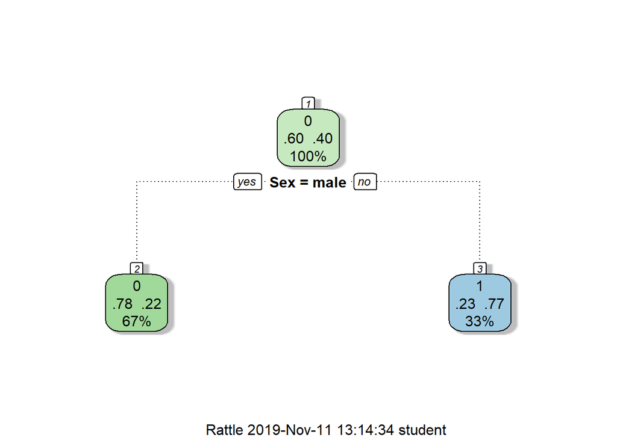

```
## Confusion Matrix and Statistics
##
##           Reference
## Prediction   0   1
##          0 111  31
##          1  16  55
##
##                Accuracy : 0.7793
##                  95% CI : (0.7176, 0.8331)
##     No Information Rate : 0.5962
##     P-Value [Acc > NIR] : 1.181e-08
##
##                   Kappa : 0.5284
##
##  Mcnemar's Test P-Value : 0.04114
##
##             Sensitivity : 0.6395
##             Specificity : 0.8740
##          Pos Pred Value : 0.7746
##          Neg Pred Value : 0.7817
##              Prevalence : 0.4038
##          Detection Rate : 0.2582
##    Detection Prevalence : 0.3333
##       Balanced Accuracy : 0.7568
##
##        'Positive' Class : 1
##
```

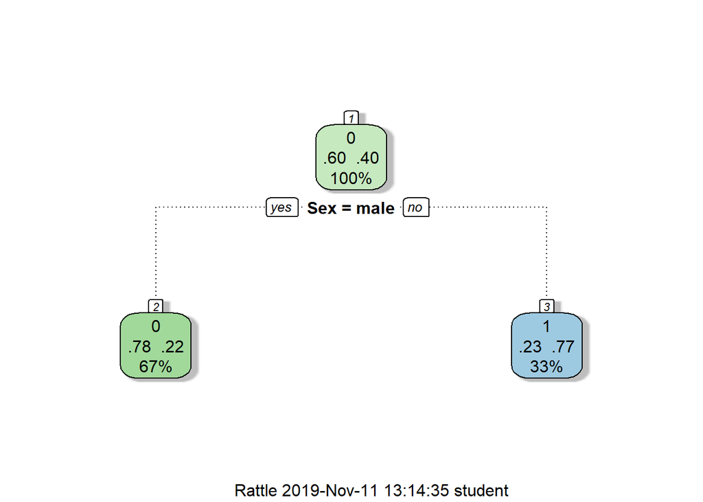

```
## Confusion Matrix and Statistics
##
##           Reference
## Prediction   0   1
##          0 111  31
##          1  16  55
##
##                Accuracy : 0.7793
##                  95% CI : (0.7176, 0.8331)
##     No Information Rate : 0.5962
##     P-Value [Acc > NIR] : 1.181e-08
##
##                   Kappa : 0.5284
##
##  Mcnemar's Test P-Value : 0.04114
##
##             Sensitivity : 0.6395
##             Specificity : 0.8740
##          Pos Pred Value : 0.7746
##          Neg Pred Value : 0.7817
##              Prevalence : 0.4038
##          Detection Rate : 0.2582
##    Detection Prevalence : 0.3333
##       Balanced Accuracy : 0.7568
##
##        'Positive' Class : 1
##
```

[figure not shown]

```
## Confusion Matrix and Statistics
##
##           Reference
## Prediction   0   1
##          0 116  25
##          1  11  61
##
##                Accuracy : 0.831
##                  95% CI : (0.7738, 0.8787)
##     No Information Rate : 0.5962
##     P-Value [Acc > NIR] : 1.29e-13
##
##                   Kappa : 0.6395
##
##  Mcnemar's Test P-Value : 0.03026
##
##             Sensitivity : 0.7093
##             Specificity : 0.9134
##          Pos Pred Value : 0.8472
##          Neg Pred Value : 0.8227
##              Prevalence : 0.4038
##          Detection Rate : 0.2864
##    Detection Prevalence : 0.3380
##       Balanced Accuracy : 0.8113
##
##        'Positive' Class : 1
##
```

[figure not shown]

```
## Confusion Matrix and Statistics
##
##           Reference
## Prediction   0   1
##          0 116  25
##          1  11  61
##
##                Accuracy : 0.831
##                  95% CI : (0.7738, 0.8787)
##     No Information Rate : 0.5962
##     P-Value [Acc > NIR] : 1.29e-13
##
##                   Kappa : 0.6395
##
##  Mcnemar's Test P-Value : 0.03026
##
##             Sensitivity : 0.7093
##             Specificity : 0.9134
##          Pos Pred Value : 0.8472
##          Neg Pred Value : 0.8227
##              Prevalence : 0.4038
##          Detection Rate : 0.2864
##    Detection Prevalence : 0.3380
##       Balanced Accuracy : 0.8113
##
##        'Positive' Class : 1
##
```

[figure not shown]

```
## Confusion Matrix and Statistics
##
##           Reference
## Prediction   0   1
##          0 116  25
##          1  11  61
##
##                Accuracy : 0.831
##                  95% CI : (0.7738, 0.8787)
##     No Information Rate : 0.5962
##     P-Value [Acc > NIR] : 1.29e-13
##
##                   Kappa : 0.6395
##
##  Mcnemar's Test P-Value : 0.03026
##
##             Sensitivity : 0.7093
##             Specificity : 0.9134
##          Pos Pred Value : 0.8472
##          Neg Pred Value : 0.8227
##              Prevalence : 0.4038
##          Detection Rate : 0.2864
##    Detection Prevalence : 0.3380
##       Balanced Accuracy : 0.8113
##
##        'Positive' Class : 1
##
```

```
## Confusion Matrix and Statistics
##
##           Reference
## Prediction   0   1
##          0 116  25
##          1  11  61
##
##                Accuracy : 0.831
##                  95% CI : (0.7738, 0.8787)
##     No Information Rate : 0.5962
##     P-Value [Acc > NIR] : 1.29e-13
##
##                   Kappa : 0.6395
##
##  Mcnemar's Test P-Value : 0.03026
##
##             Sensitivity : 0.7093
##             Specificity : 0.9134
##          Pos Pred Value : 0.8472
##          Neg Pred Value : 0.8227
##              Prevalence : 0.4038
##          Detection Rate : 0.2864
##    Detection Prevalence : 0.3380
##       Balanced Accuracy : 0.8113
##
##        'Positive' Class : 1
##
```

[figure not shown]

```
## Confusion Matrix and Statistics
##
##           Reference
## Prediction   0   1
##          0 116  25
##          1  11  61
##
##                Accuracy : 0.831
##                  95% CI : (0.7738, 0.8787)
##     No Information Rate : 0.5962
##     P-Value [Acc > NIR] : 1.29e-13
##
##                   Kappa : 0.6395
##
##  Mcnemar's Test P-Value : 0.03026
##
##             Sensitivity : 0.7093
##             Specificity : 0.9134
##          Pos Pred Value : 0.8472
##          Neg Pred Value : 0.8227
##              Prevalence : 0.4038
##          Detection Rate : 0.2864
##    Detection Prevalence : 0.3380
##       Balanced Accuracy : 0.8113
##
##        'Positive' Class : 1
##
```

[figure not shown]

```
## Confusion Matrix and Statistics
##
##           Reference
## Prediction   0   1
##          0 116  25
##          1  11  61
##
##                Accuracy : 0.831
##                  95% CI : (0.7738, 0.8787)
##     No Information Rate : 0.5962
##     P-Value [Acc > NIR] : 1.29e-13
##
##                   Kappa : 0.6395
##
##  Mcnemar's Test P-Value : 0.03026
##
##             Sensitivity : 0.7093
##             Specificity : 0.9134
##          Pos Pred Value : 0.8472
##          Neg Pred Value : 0.8227
##              Prevalence : 0.4038
##          Detection Rate : 0.2864
##    Detection Prevalence : 0.3380
##       Balanced Accuracy : 0.8113
##
##        'Positive' Class : 1
##
```

```
## Confusion Matrix and Statistics
##
##           Reference
## Prediction   0   1
##          0 116  25
##          1  11  61
##
##                Accuracy : 0.831
##                  95% CI : (0.7738, 0.8787)
##     No Information Rate : 0.5962
##     P-Value [Acc > NIR] : 1.29e-13
##
##                   Kappa : 0.6395
##
##  Mcnemar's Test P-Value : 0.03026
##
##             Sensitivity : 0.7093
##             Specificity : 0.9134
##          Pos Pred Value : 0.8472
##          Neg Pred Value : 0.8227
##              Prevalence : 0.4038
##          Detection Rate : 0.2864
##    Detection Prevalence : 0.3380
##       Balanced Accuracy : 0.8113
##
##        'Positive' Class : 1
##
```

[figure not shown]

```
## Confusion Matrix and Statistics
##
##           Reference
## Prediction   0   1
##          0 116  25
##          1  11  61
##
##                Accuracy : 0.831
##                  95% CI : (0.7738, 0.8787)
##     No Information Rate : 0.5962
##     P-Value [Acc > NIR] : 1.29e-13
##
##                   Kappa : 0.6395
##
##  Mcnemar's Test P-Value : 0.03026
##
##             Sensitivity : 0.7093
##             Specificity : 0.9134
##          Pos Pred Value : 0.8472
##          Neg Pred Value : 0.8227
##              Prevalence : 0.4038
##          Detection Rate : 0.2864
##    Detection Prevalence : 0.3380
##       Balanced Accuracy : 0.8113
##
##        'Positive' Class : 1
##
```

```r
for (value in 1:10) {
jefftree <- rpart(target ~ ., data = test, method = "class", control = rpart.control(maxdepth = value))
fancyRpartPlot(jefftree)
print(confusionMatrix(data = predict(jefftree,test, type = "class"), reference = factor(test$target), positive = "1"))
}
```